# Analyse der Kunden

[output not shown]

# Gruppierung der Kunden

Wir versuchen anhand verschiedener Kriterien leicht zugängliche Gruppen von Kunden zu ermitteln.

Die Fragen, die wir uns stellten lauten:

- Gibt es Kunden die häufig wiederkehren? Was ist das durchschnittliche Intervall der Wiederkehrer?
- Gibt es bestimmte Produkte, welche von Ersteinkäufern erlangt werden? Was lockt die Kunden in den Laden?
- Gibt es Kunden, welche häufig nur kleine, aber dafür regelmässige Einkäufe tätigen?
- Gibt es Kunden, welche Bio kaufen und welche gar kein Bio kaufen?
- Wie verhält sich die Länge der Kundschaft zum Anteil von gekauften Bio Produkten?

## Häufigkeit der Einkäufe

```r
customer_behavior %>%
  select(total_nr_of_orders) %>%
  summary()
```

```
 total_nr_of_orders
 Min.   :  4.00
 1st Qu.:  6.00
 Median : 10.00
 Mean   : 16.59
 3rd Qu.: 20.00
 Max.   :100.00
```

## Grösse der Warenkörbe

```r
customer_behavior %>%
  select(mean_products_per_order) %>%
  summary()
```

[output not shown]

[figure not shown]

```r
customer_behavior %>%
  ggplot(aes(x=total_nr_of_orders)) +
    xlab("Average products bought per order") +
    ylab("Customer count") +
    ggtitle("How many orders are done by 'normal' users?") +
    geom_histogram(binwidth = 2, color="darkgray")
```

```r
customer_behavior %>%
  select(total_product_count) %>%
  summary()
```

```
 total_product_count
 Min.   :   3
 1st Qu.:  44
 Median :  90
 Mean   : 164
 3rd Qu.: 196
 Max.   :3725
```

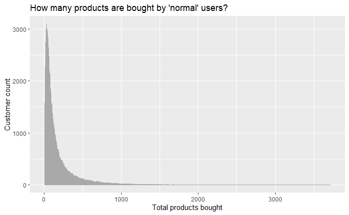

```r
customer_behavior %>%
  ggplot(aes(x=total_product_count)) +
    xlab("Total products bought") +
    ylab("Customer count") +
    ggtitle("How many products are bought by 'normal' users?") +
    geom_histogram(binwidth = 2, color="darkgray")
```

## Durchschnittliche Einkaufsfrequenz

Wie häufig kommen Kunden im Durchschnitt in den Laden (aller wieviel Tage)?

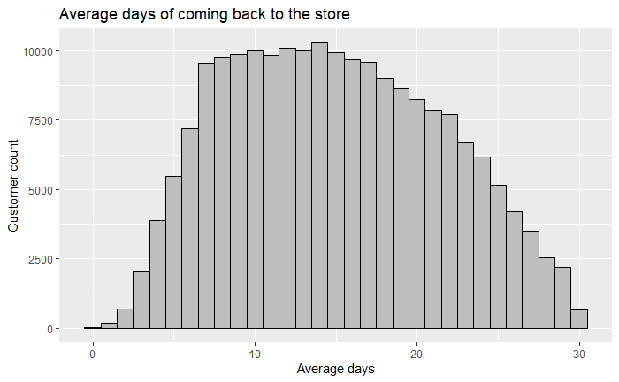

```r
customer_behavior %>%
  filter(avg_days_since_prior_order < 30) %>% #laut Beschreibung der Daten bedeutet 30 hier "30 und mehr"
  ggplot(aes(x=avg_days_since_prior_order)) +
    xlab("Average days") +
    ylab("Customer count") +
    ggtitle("Average days of coming back to the store") +
    geom_histogram(binwidth = 1, color="black", fill="gray")
```

```r
customer_behavior %>%
  filter(avg_days_since_prior_order < 30) %>%
  select(avg_days_since_prior_order) %>%
  summary()
```

```
 avg_days_since_prior_order
 Min.   : 0.000
 1st Qu.: 9.667
 Median :14.667
 Mean   :15.044
 3rd Qu.:20.111
 Max.   :29.889
```

Etwas mehr als die Hälfte aller Kunden kommen aller 9 bis 20 Tage zurück um erneut etwas zu kaufen. Im Durchschnitt aller 15 Tage.

## Wie hoch ist der Anteil derer, die nur einmal einkaufen?

```r
customer_behavior %>%
  filter(total_nr_of_orders == 1)
```

| user_id | total_nr_of_orders | avg_days_since_prior_order | timespan_for_all_orders | mean_products_per_order | median_products_per_order | min_products_per_order | max_products_per_order | total_product_count | mean_bio_products_per_order | median_bio_products_per_order | min_bio_products_per_order | max_bio_products_per_order | total_bio_product_count | fraction_mean_bio | fraction_median_bio |
| --- | --- | --- | --- | --- | --- | --- | --- | --- | --- | --- | --- | --- | --- | --- | --- |

Es gibt keine Daten zu “Einmalkunden”. Vielleicht sind diese bereits gefiltert worden.

## Wie ist das Verhältnis von Anzahl der Bestellungen zu Warenkorbgrösse?

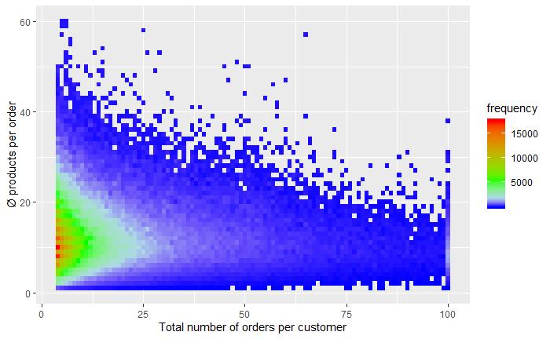

```r
customer_behavior %>%
  mutate(mean_products_per_order = round(mean_products_per_order)) %>%
  group_by(total_nr_of_orders, mean_products_per_order) %>%
  summarise(weight = sum(mean_products_per_order)) %>%
  ggplot(aes(x=total_nr_of_orders, y=mean_products_per_order, fill=weight)) +
    geom_tile() +
    scale_fill_gradientn(colors = c("blue", "lightblue", "green", "red"), values = c(0,0.1, 0.3, 1)) +
    labs(x = "Total number of orders per customer", y = "Ø products per order", fill = "frequency", title = NULL)
```

Man sieht eine hohe Konzentration zwischen 5 und 15 Produkten und bis 8 Aufträge pro Kunde.

# Stammkunden herausfiltern

Aufgrund der obigen Auswertungen definieren wir definieren Stammkunden Attribute:

- Zeitraum über alle Einkäufe mindestens 90 Tage
- Frequenz der Einkäufe im Durchschnitt mindestens alle 15 Tage

## Verhältnis von Stammkunden zu allen Kunden

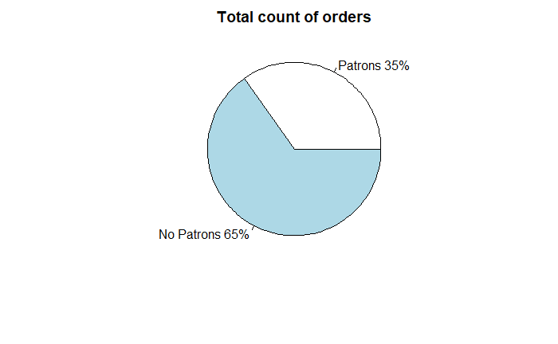

```r
patrons_count <- patrons %>%
  count() %>%
  pull(n) %>%
  as.numeric()

no_patrons_count <- orders %>%
  select(user_id) %>%
  distinct() %>%
  count() %>%
  pull(n) %>%
  as.numeric() - patrons_count

slices <- c(patrons_count, no_patrons_count)
lbls <- c("Patrons", "No Patrons")
order_pct <- round(slices/sum(slices)*100)
lbls <- paste(lbls, order_pct) # add percents to labels
lbls <- paste(lbls,"%",sep="") # ad % to labels

pie(slices, lbls, main="Total count of orders")
```

## Verhältnis von Einkäufen von Stammkunden zu Nichtstammkunden

```r
products_patron_ratio <- products_count_by_user %>%
  inner_join(products) %>%
  left_join(patrons %>% mutate(patron = TRUE)) %>%
  mutate(patron = replace_na(patron, FALSE)) %>%
  group_by(product_name, patron) %>%
  summarise(count = sum(count)) %>%
  spread(key=patron, value = count) %>%
  rename(no_patrons_bought = 'FALSE', patrons_bought = 'TRUE') %>%
  mutate(no_patrons_bought = replace_na(no_patrons_bought, 0)) %>%
  mutate(patrons_bought = replace_na(patrons_bought, 0)) %>%
  mutate(overall_bought = no_patrons_bought + patrons_bought) %>%
  as_tibble()
```

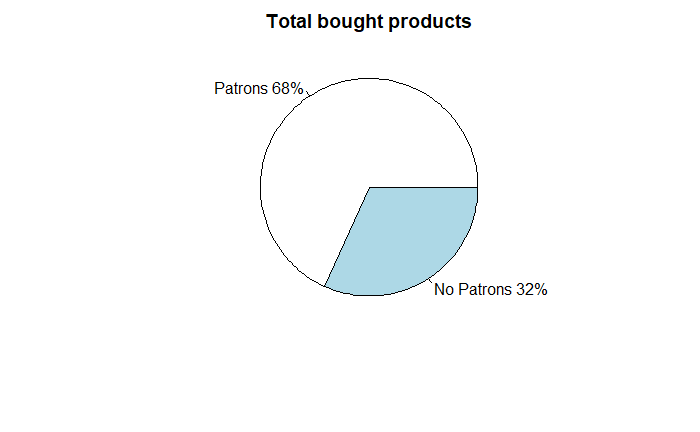

```r
slices <- c(sum(products_patron_ratio$patrons_bought), sum(products_patron_ratio$no_patrons_bought))
lbls <- c("Patrons", "No Patrons")
products_pct <- round(slices/sum(slices)*100)
lbls <- paste(lbls, products_pct) # add percents to labels
lbls <- paste(lbls,"%",sep="") # ad % to labels

pie(slices, lbls, main="Total bought products")
```

Die Stammkunden sind für 68% aller gekauften Produkte verantwortlich.

**35% aller Kunden sind für 68% aller gekauften Produkte verantwortlich.**

## Wie ist die Verteilung der Topprodukte zu Stammkunden und nicht Stammkunden

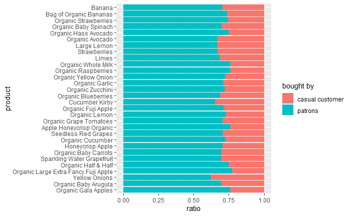

```r
products_patron_ratio %>%
  arrange(desc(overall_bought)) %>%
  top_n(30) %>%
  gather(`patrons_bought`, `no_patrons_bought`, key="class", value="count") %>%
  mutate(class = ifelse(grepl('no_patrons_bought', class), 'casual customer', 'patrons')) %>%
  ggplot(aes(x=reorder(product_name,count), y=count, fill=class)) +
    geom_col(position="fill") +
    coord_flip() +
    labs(x = "product", y = "ratio", fill = "bought by")
```

Es gibt leichte Unterschiede im Kaufverhalten von Stammkunden und Nicht-Stammkunden. Diese sind aber tendenziell vernachlässigbar.

# Neukunden auswerten

## Warenkorbgrösse von Neukunden

```r
orders %>%
  filter(is.na(days_since_prior_order)) %>%
  group_by(user_id) %>%
  summarise(count = n()) %>%
  select(count) %>%
  summary()
```

```
     count
 Min.   : 1.00
 1st Qu.: 5.00
 Median : 8.00
 Mean   :10.08
 3rd Qu.:14.00
 Max.   :98.00
```

# Kaufverhalten von Bio Produkten

## Durchschnittliche Anzahl an Bioprodukten im Warenkorb

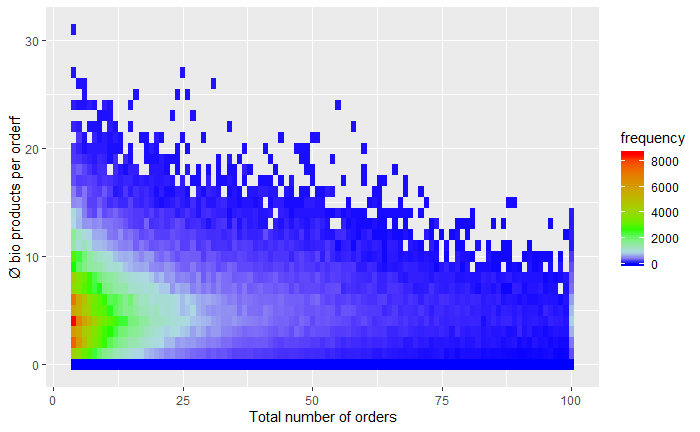

```r
customer_behavior %>%
  mutate(mean_bio_products_per_order = round(mean_bio_products_per_order)) %>%
  group_by(total_nr_of_orders, mean_bio_products_per_order) %>%
  summarise(weight = sum(mean_bio_products_per_order)) %>%
  ggplot(aes(x=total_nr_of_orders, y=mean_bio_products_per_order, fill=weight)) +
    geom_tile() +
    scale_fill_gradientn(colors = c("blue", "lightblue", "green", "red"), values = c(0,0.1, 0.3, 1)) +
    labs(x = "Total number of orders", y = "Ø bio products per orderf", fill = "frequency", title = NULL)
```

## Verhältnis von Bioprodukten

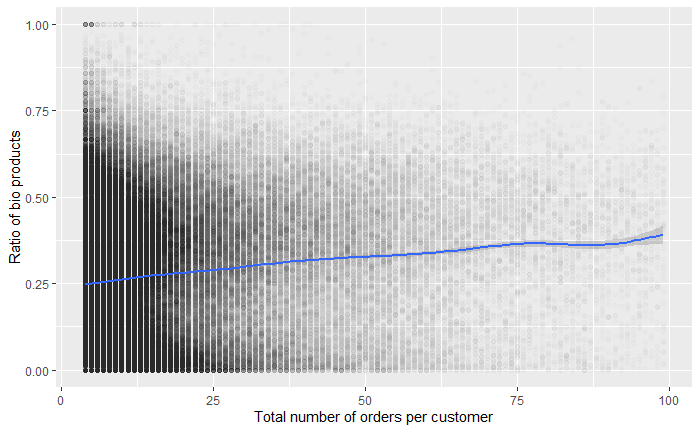

```r
customer_behavior %>%
  filter(total_nr_of_orders < 100) %>%
  ggplot(aes(x=total_nr_of_orders, y=fraction_mean_bio)) +
    geom_point(alpha = 0.01) +
    geom_smooth() +
    labs(x = "Total number of orders per customer", y = "Ratio of bio products", title = NULL)
```

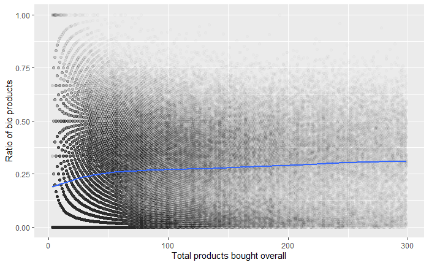

```r
customer_behavior %>%
  filter(total_product_count < 300) %>%
  ggplot(aes(x=total_product_count, y=fraction_mean_bio)) +
    geom_point(alpha = 0.01) +
    geom_smooth() +
    labs(x = "Total products bought overall", y = "Ratio of bio products", title = NULL)
```

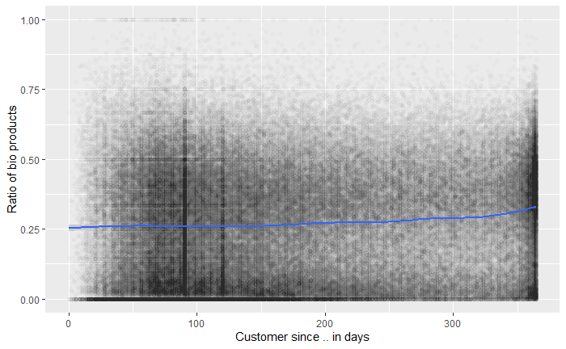

```r
customer_behavior %>%
  ggplot(aes(x=timespan_for_all_orders, y=fraction_mean_bio)) +
    geom_point(alpha = 0.01) +
    geom_smooth() +
    labs(x = "Customer since .. in days", y = "Ratio of bio products", title = NULL)
```

In allen drei Graphen kann man sehen, dass der Bioanteil bei grösserer Nutzung (häufigere Einkäufe, mehr gekaufte Produkte, etc.) des Stores ansteigt.

# Zusammenfassung

- 35% aller Kunden sind für 68% aller gekauften Produkte verantwortlich
- Stammkunden kaufen i.d.R. nicht andere Produkte als andere Kunden
- Je länger ein Kunde im Store einkauft bzw. desto mehr oder häufiger er kauft, desto mehr Bioprodukte werden gekauft
- allgemein kann man sagen, dass es einen Trend für Bioprodukte gibt

# Ricci Kritik

- costumer_behavior kurz erklären
- Behäschtägung mit Nummern und eventuell in Frage und Antwort aufteilen.
- Titel in den unteten Graphen fehlt